# Find Suitable Locations for a New Campsite in Yosemite

## Setup

Load the packages we’ll need and set tmap mode to ‘plot’:

```r
library(sf)
library(raster)
library(dplyr)
library(tmap)
tmap_mode("plot")
```

```
tmap mode set to plotting
```

```r
## Load the conflicted package
library(conflicted)
conflict_prefer("filter", "dplyr", quiet = TRUE)
conflict_prefer("count", "dplyr", quiet = TRUE)
conflict_prefer("select", "dplyr", quiet = TRUE)
conflict_prefer("arrange", "dplyr", quiet = TRUE)
```

## Import Layers for Yosemite National Park

For this analysis we’ll need the park boundary, the watersheds, and a DEM (elevation) of the park. At the same time, we’ll project everything to UTM.

```r
epsg_utm11n_wgs84 <- 32611
epsg_geo_wgs84 <- 4326

## Import the park boundary
bnd_fn <- "./data/yose_boundary.shp"
file.exists(bnd_fn)
```

```
[1] TRUE
```

```r
yose_bnd_utm <- st_read(bnd_fn) %>%
  st_transform(epsg_utm11n_wgs84)
yose_wtrshds_utm <- st_read("./data/yose_watersheds.gpkg", layer="calw221") %>%
  st_transform(epsg_utm11n_wgs84)
```

Plot to verify:

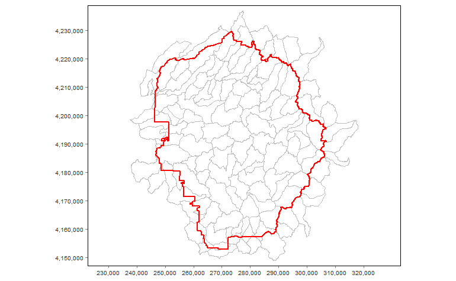

```r
tm_shape(yose_wtrshds_utm) +
  tm_borders(col = "gray", lwd = 1) +
tm_shape(yose_bnd_utm) +
  tm_borders(col = "red", lwd = 2) +
tm_grid(lines = FALSE) +
tm_layout(legend.outside = TRUE,
          asp = 1.2)
```

## Import the DEM

We have elevation data in the form of a tile of SRTM data.

```r
srtm1305_fn <- "./data/srtm_13_05.tif"
file.exists(srtm1305_fn)
```

```
[1] TRUE
```

```r
srtm1305_rst <- raster(srtm1305_fn)
srtm1305_rst
```

```
class      : RasterLayer
dimensions : 6001, 6001, 36012001  (nrow, ncol, ncell)
resolution : 0.0008333333, 0.0008333333  (x, y)
extent     : -120.0004, -114.9996, 34.99958, 40.00042  (xmin, xmax, ymin, ymax)
crs        : +proj=longlat +datum=WGS84 +no_defs
source     : srtm_13_05.tif
names      : srtm_13_05
values     : -32768, 32767  (min, max)
```

## Crop the DEM to the Park Boundary

We can crop the large DEM to the park boundary using `raster::crop()`. Remember that the raster and the layer for the crop area need to be in the same CRS, so we transform the park boundary to geographic coordinates.

```r
yose_bnd_ll <- yose_bnd_utm %>% st_transform(epsg_geo_wgs84)

yose_dem_rst_ll <- raster::crop(srtm1305_rst, yose_bnd_ll)

yose_dem_rst_ll
```

```
class      : RasterLayer
dimensions : 829, 828, 686412  (nrow, ncol, ncell)
resolution : 0.0008333333, 0.0008333333  (x, y)
extent     : -119.8863, -119.1963, 37.49458, 38.18542  (xmin, xmax, ymin, ymax)
crs        : +proj=longlat +datum=WGS84 +no_defs
source     : memory
names      : srtm_13_05
values     : 436, 3971  (min, max)
```

Plot to verify:

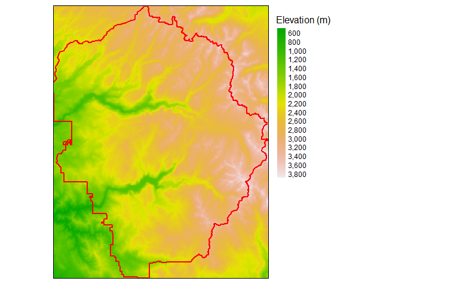

```r
tm_shape(yose_dem_rst_ll) +
  tm_raster(title = "Elevation (m)", style = "cont", n = 15, palette = terrain.colors(256)) +
tm_shape(yose_bnd_ll) +
  tm_borders(col = "red", lwd = 2) +
tm_legend(outside = TRUE)
```

## Reproject the Clipped Raster

Lastly, we need to project the park DEM into UTM using `projectRaster()` with the following arguments:

- `from`: the raster we want to project
- `to`: omitted in this case (because we’re supplying `crs` and `res`)
- `crs`: pass a proj4 string
- `res`: resolution in map units (which in the case of UTM is meters)
- `method`: choose ‘blinear’ but the cell values (elevation MSL) are continuous, and we want the interpolated values to also be continuous

```r
## Define the proj4 string for UTM 11N
utm11n_wgs84_proj4 <- "+init=epsg:32611"

yose_dem_rst_utm <- projectRaster(from = yose_dem_rst_ll,
                              crs = CRS(utm11n_wgs84_proj4),
                              res = 90,
                              method = "bilinear")
```

[output not shown]

```r
yose_dem_rst_utm
```

```
class      : RasterLayer
dimensions : 880, 708, 623040  (nrow, ncol, ncell)
resolution : 90, 90  (x, y)
extent     : 244387.5, 308107.5, 4151576, 4230776  (xmin, xmax, ymin, ymax)
crs        : +proj=utm +zone=11 +datum=WGS84 +units=m +no_defs
source     : memory
names      : srtm_13_05
values     : 440.8224, 3958.44  (min, max)
```

Plot to make sure it worked:

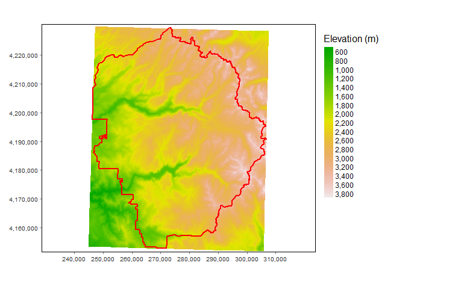

```r
tm_shape(yose_dem_rst_utm) +
  tm_raster(title = "Elevation (m)", style = "cont", n = 15, palette = terrain.colors(256)) +
tm_shape(yose_bnd_utm) +
  tm_borders(col = "red", lwd = 2) +
tm_grid(lines = FALSE) +
tm_layout(legend.outside = TRUE,
          asp = 1.2)
```

CHALLENGE: Compute average elevation per watershed.

```r
## Your answer here
```

## Compute Slope

Slope is one of the criteria for our campsite. We can compute the slope from the DEM using the `raster::terrain()`:

```r
yose_slope_rst <- raster::terrain(yose_dem_rst_utm, opt="slope")
yose_slope_rst
```

```
class      : RasterLayer
dimensions : 880, 708, 623040  (nrow, ncol, ncell)
resolution : 90, 90  (x, y)
extent     : 244387.5, 308107.5, 4151576, 4230776  (xmin, xmax, ymin, ymax)
crs        : +proj=utm +zone=11 +datum=WGS84 +units=m +no_defs
source     : memory
names      : slope
values     : 0, 1.242767  (min, max)
```

Plot to make sure it worked. Note that slope is measured in [radians](https://en.wikipedia.org/wiki/Radian).

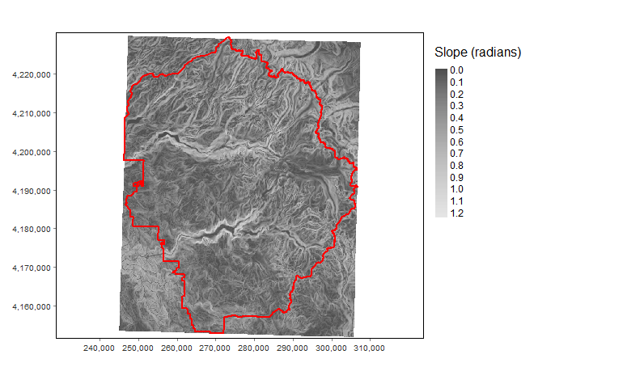

```r
tm_shape(yose_slope_rst) +
  tm_raster(title = "Slope (radians)", style = "cont", n = 15, palette = gray.colors(256)) +
tm_shape(yose_bnd_utm) +
  tm_borders(col = "red", lwd = 2) +
tm_grid(lines = FALSE) +
tm_layout(legend.outside = TRUE,
          asp = 1.2)
```

## CHALLENGE: Add one more criteria

Add one more criteria - exclude areas within 100m of an existing campsite. Hint: campsites are included in the `yose_poi.shp` layer. [Answer](https://bit.ly/2OnnFxA)

## End

Congratulations, you completed another R Notebook.

Save your Notebook to generate a HTML preview of the code you ran.